# Individual Assignment 4: Association Rules by Shimony Agrawal

Download the necessary packages for Market Basket Analysis and Association Rules.

```r
library(DBI)
library(odbc)
library(tidyverse)
library(lubridate)
library(dplyr)
library(ggplot2)
library(arules)
library(arulesViz)
```

Part 1: Load the data set.

```r
data(Groceries)
str(Groceries)
```

```
Formal class 'transactions' [package "arules"] with 3 slots
  ..@ data       :Formal class 'ngCMatrix' [package "Matrix"] with 5 slots
  .. .. ..@ i       : int [1:43367] 13 60 69 78 14 29 98 24 15 29 ...
  .. .. ..@ p       : int [1:9836] 0 4 7 8 12 16 21 22 27 28 ...
  .. .. ..@ Dim     : int [1:2] 169 9835
  .. .. ..@ Dimnames:List of 2
  .. .. .. ..$ : NULL
  .. .. .. ..$ : NULL
  .. .. ..@ factors : list()
  ..@ itemInfo   :'data.frame': 169 obs. of  3 variables:
  .. ..$ labels: chr [1:169] "frankfurter" "sausage" "liver loaf" "ham" ...
  .. ..$ level2: Factor w/ 55 levels "baby food","bags",..: 44 44 44 44 44 44 44 42 42 41 ...
  .. ..$ level1: Factor w/ 10 levels "canned food",..: 6 6 6 6 6 6 6 6 6 6 ...
  ..@ itemsetInfo:'data.frame': 0 obs. of  0 variables
```

```r
dim(Groceries)
```

```
[1] 9835  169
```

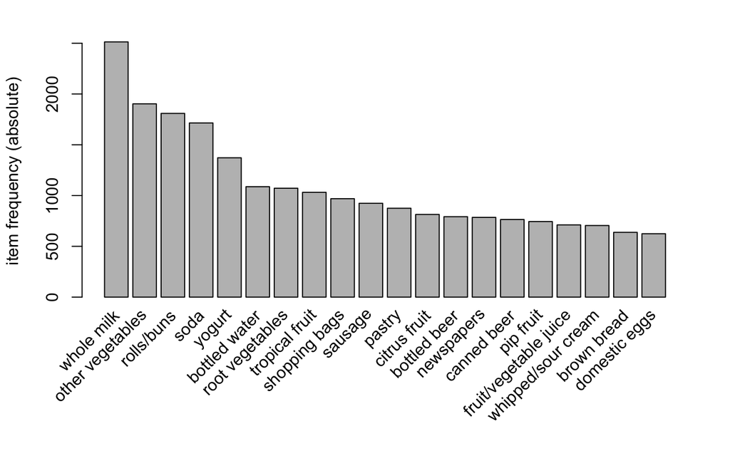

```r
itemFrequencyPlot(Groceries,topN=20,type="absolute")

support = 0.05
itemsets <- apriori(Groceries,
                    parameter = list(target = "frequent itemsets", supp = support, conf = 0.60, minlen = 2),
                    control = list (verbose = FALSE))

par(mar = c(5,14,2,2)+.1)
```

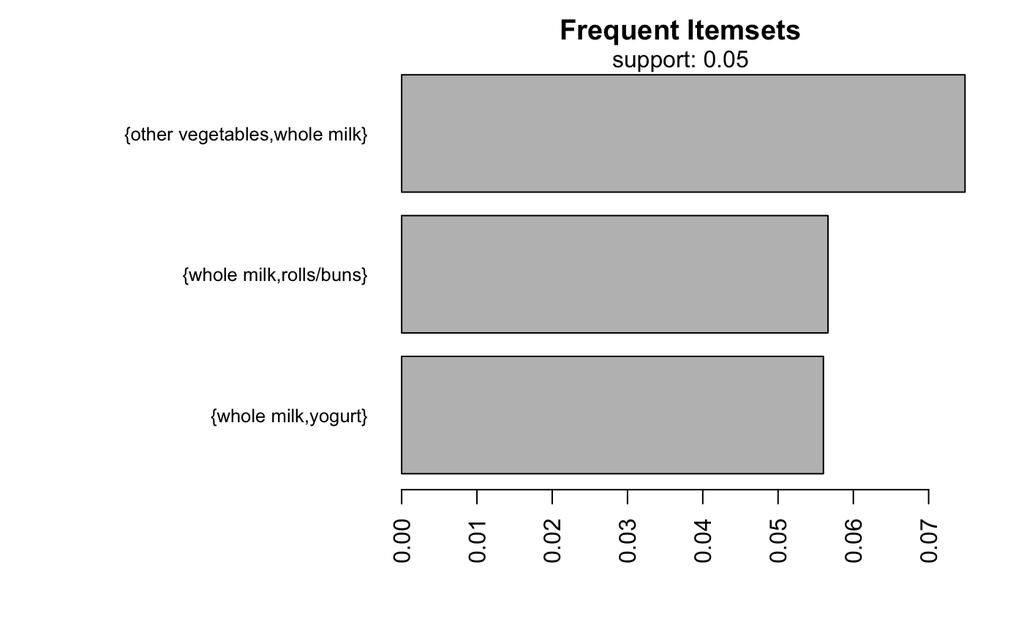

```r
order_sets <- DATAFRAME(sort(itemsets, by = "support", decreasing = F))
barplot(order_sets$support, names.arg = order_sets$items,
        horiz = T, las = 2, cex.names = .8, main = "Frequent Itemsets")
mtext(paste("support:", support), padj = .8)
```

Part 2: Use the apriori algorithm to identify the top 20 rules.

```r
# Get the rules
rules <- apriori(Groceries, parameter = list(supp = 0.001, conf = 0.8))
```

```
Apriori

Parameter specification:
```

|  | confidence | minval | smax | arem | aval | originalSupport | maxtime | support | minlen | maxlen | target | ext |
| --- | --- | --- | --- | --- | --- | --- | --- | --- | --- | --- | --- | --- |
|  | 0.8 | 0.1 | 1 | none | FALSE | TRUE | 5 | 0.001 | 1 | 10 | rules | TRUE |

```
Algorithmic control:
```

|  | filter | tree | heap | memopt | load | sort | verbose |
| --- | --- | --- | --- | --- | --- | --- | --- |
|  | 0.1 | TRUE | TRUE | FALSE | TRUE | 2 | TRUE |

```
Absolute minimum support count: 9

set item appearances ...[0 item(s)] done [0.00s].
set transactions ...[169 item(s), 9835 transaction(s)] done [0.01s].
sorting and recoding items ... [157 item(s)] done [0.00s].
creating transaction tree ... done [0.01s].
checking subsets of size 1 2 3 4 5 6 done [0.03s].
writing ... [410 rule(s)] done [0.01s].
creating S4 object  ... done [0.02s].
```

```r
# Show the top 20  rules
arules::inspect(rules[1:20])
```

|  | lhs |  | rhs | support | confidence | coverage | lift | count |
| --- | --- | --- | --- | --- | --- | --- | --- | --- |
| [1] | {liquor,red/blush wine} | => | {bottled beer} | 0.0019 | 0.90 | 0.0021 | 11.2 | 19 |
| [2] | {curd,cereals} | => | {whole milk} | 0.0010 | 0.91 | 0.0011 | 3.6 | 10 |
| [3] | {yogurt,cereals} | => | {whole milk} | 0.0017 | 0.81 | 0.0021 | 3.2 | 17 |
| [4] | {butter,jam} | => | {whole milk} | 0.0010 | 0.83 | 0.0012 | 3.3 | 10 |
| [5] | {soups,bottled beer} | => | {whole milk} | 0.0011 | 0.92 | 0.0012 | 3.6 | 11 |
| [6] | {napkins,house keeping products} | => | {whole milk} | 0.0013 | 0.81 | 0.0016 | 3.2 | 13 |
| [7] | {whipped/sour cream,house keeping products} | => | {whole milk} | 0.0012 | 0.92 | 0.0013 | 3.6 | 12 |
| [8] | {pastry,sweet spreads} | => | {whole milk} | 0.0010 | 0.91 | 0.0011 | 3.6 | 10 |
| [9] | {turkey,curd} | => | {other vegetables} | 0.0012 | 0.80 | 0.0015 | 4.1 | 12 |
| [10] | {rice,sugar} | => | {whole milk} | 0.0012 | 1.00 | 0.0012 | 3.9 | 12 |

[output cut: 10 more lines]

```r
summary(rules)
```

```
set of 410 rules

rule length distribution (lhs + rhs):sizes
  3   4   5   6
 29 229 140  12

   Min. 1st Qu.  Median    Mean 3rd Qu.    Max.
    3.0     4.0     4.0     4.3     5.0     6.0

summary of quality measures:
    support          confidence      coverage           lift          count
 Min.   :0.00102   Min.   :0.80   Min.   :0.0010   Min.   : 3.1   Min.   :10.0
 1st Qu.:0.00102   1st Qu.:0.83   1st Qu.:0.0012   1st Qu.: 3.3   1st Qu.:10.0
 Median :0.00122   Median :0.85   Median :0.0013   Median : 3.6   Median :12.0
 Mean   :0.00125   Mean   :0.87   Mean   :0.0014   Mean   : 4.0   Mean   :12.3
 3rd Qu.:0.00132   3rd Qu.:0.91   3rd Qu.:0.0016   3rd Qu.: 4.3   3rd Qu.:13.0
 Max.   :0.00315   Max.   :1.00   Max.   :0.0036   Max.   :11.2   Max.   :31.0

mining info:
```

|  | data | ntransactions | support | confidence |
| --- | --- | --- | --- | --- |
|  | Groceries | 9835 | 0.001 | 0.8 |

```r
rules<-sort(rules, by="confidence", decreasing=TRUE)
rules <- apriori(Groceries, parameter = list(supp = 0.001, conf = 0.8, maxlen=3))
```

```
Apriori

Parameter specification:
```

|  | confidence | minval | smax | arem | aval | originalSupport | maxtime | support | minlen | maxlen | target | ext |
| --- | --- | --- | --- | --- | --- | --- | --- | --- | --- | --- | --- | --- |
|  | 0.8 | 0.1 | 1 | none | FALSE | TRUE | 5 | 0.001 | 1 | 3 | rules | TRUE |

```
Algorithmic control:
```

|  | filter | tree | heap | memopt | load | sort | verbose |
| --- | --- | --- | --- | --- | --- | --- | --- |
|  | 0.1 | TRUE | TRUE | FALSE | TRUE | 2 | TRUE |

```
Absolute minimum support count: 9

set item appearances ...[0 item(s)] done [0.00s].
set transactions ...[169 item(s), 9835 transaction(s)] done [0.01s].
sorting and recoding items ... [157 item(s)] done [0.00s].
creating transaction tree ... done [0.00s].
checking subsets of size 1 2 3
```

```
Mining stopped (maxlen reached). Only patterns up to a length of 3 returned!
```

```
 done [0.01s].
writing ... [29 rule(s)] done [0.00s].
creating S4 object  ... done [0.01s].
```

```r
summary(rules)
```

```
set of 29 rules

rule length distribution (lhs + rhs):sizes
 3
29

   Min. 1st Qu.  Median    Mean 3rd Qu.    Max.
      3       3       3       3       3       3

summary of quality measures:
    support          confidence      coverage            lift          count
 Min.   :0.00102   Min.   :0.80   Min.   :0.00112   Min.   : 3.1   Min.   :10.0
 1st Qu.:0.00112   1st Qu.:0.81   1st Qu.:0.00122   1st Qu.: 3.3   1st Qu.:11.0
 Median :0.00122   Median :0.85   Median :0.00153   Median : 3.6   Median :12.0
 Mean   :0.00147   Mean   :0.86   Mean   :0.00173   Mean   : 4.0   Mean   :14.5
 3rd Qu.:0.00173   3rd Qu.:0.91   3rd Qu.:0.00214   3rd Qu.: 4.2   3rd Qu.:17.0
 Max.   :0.00254   Max.   :1.00   Max.   :0.00315   Max.   :11.2   Max.   :25.0

mining info:
```

|  | data | ntransactions | support | confidence |
| --- | --- | --- | --- | --- |
|  | Groceries | 9835 | 0.001 | 0.8 |

```r
arules::inspect(rules[1:20])
```

|  | lhs |  | rhs | support | confidence | coverage | lift | count |
| --- | --- | --- | --- | --- | --- | --- | --- | --- |
| [1] | {liquor,red/blush wine} | => | {bottled beer} | 0.0019 | 0.90 | 0.0021 | 11.2 | 19 |
| [2] | {curd,cereals} | => | {whole milk} | 0.0010 | 0.91 | 0.0011 | 3.6 | 10 |
| [3] | {yogurt,cereals} | => | {whole milk} | 0.0017 | 0.81 | 0.0021 | 3.2 | 17 |
| [4] | {butter,jam} | => | {whole milk} | 0.0010 | 0.83 | 0.0012 | 3.3 | 10 |
| [5] | {soups,bottled beer} | => | {whole milk} | 0.0011 | 0.92 | 0.0012 | 3.6 | 11 |
| [6] | {napkins,house keeping products} | => | {whole milk} | 0.0013 | 0.81 | 0.0016 | 3.2 | 13 |
| [7] | {whipped/sour cream,house keeping products} | => | {whole milk} | 0.0012 | 0.92 | 0.0013 | 3.6 | 12 |
| [8] | {pastry,sweet spreads} | => | {whole milk} | 0.0010 | 0.91 | 0.0011 | 3.6 | 10 |
| [9] | {turkey,curd} | => | {other vegetables} | 0.0012 | 0.80 | 0.0015 | 4.1 | 12 |
| [10] | {rice,sugar} | => | {whole milk} | 0.0012 | 1.00 | 0.0012 | 3.9 | 12 |

[output cut: 10 more lines]

```r
NA
```

Part 5: Targeting items from the Top 20 items based on frequency.

```r
# RHS rules
rules<-apriori(data=Groceries, parameter=list(supp=0.001,conf = 0.08),
               appearance = list(default="lhs",rhs="soda"),
               control = list(verbose=F))
rules<-sort(rules, decreasing=TRUE,by="confidence")
arules::inspect(rules[1:10])
```

|  | lhs |  | rhs | support | confidence | coverage | lift | count |
| --- | --- | --- | --- | --- | --- | --- | --- | --- |
| [1] | {coffee,misc. beverages} | => | {soda} | 0.0010 | 0.77 | 0.0013 | 4.4 | 10 |
| [2] | {yogurt,rolls/buns,bottled water,newspapers} | => | {soda} | 0.0010 | 0.77 | 0.0013 | 4.4 | 10 |
| [3] | {sausage,bottled water,bottled beer} | => | {soda} | 0.0011 | 0.73 | 0.0015 | 4.2 | 11 |
| [4] | {sausage,white bread,shopping bags} | => | {soda} | 0.0010 | 0.67 | 0.0015 | 3.8 | 10 |
| [5] | {rolls/buns,bottled water,chocolate} | => | {soda} | 0.0013 | 0.65 | 0.0020 | 3.7 | 13 |
| [6] | {pastry,misc. beverages} | => | {soda} | 0.0012 | 0.63 | 0.0019 | 3.6 | 12 |
| [7] | {rolls/buns,chocolate,candy} | => | {soda} | 0.0012 | 0.63 | 0.0019 | 3.6 | 12 |
| [8] | {frankfurter,yogurt,bottled water} | => | {soda} | 0.0013 | 0.59 | 0.0022 | 3.4 | 13 |
| [9] | {yogurt,rolls/buns,canned beer} | => | {soda} | 0.0010 | 0.59 | 0.0017 | 3.4 | 10 |
| [10] | {other vegetables,whole milk,rolls/buns,chocolate} | => | {soda} | 0.0010 | 0.59 | 0.0017 | 3.4 | 10 |

```r
toprules_soda <- (rules[1:10])
plot(toprules_soda, method = 'graph', engine = 'htmlwidget')
```

[interactive chart not shown]

```r
rules<-apriori(data=Groceries, parameter=list(supp=0.001,conf = 0.08),
               appearance = list(default="lhs",rhs="whole milk"),
               control = list(verbose=F))
rules<-sort(rules, decreasing=TRUE,by="confidence")
arules::inspect(rules[1:10])
```

|  | lhs |  | rhs | support | confidence | coverage | lift | count |
| --- | --- | --- | --- | --- | --- | --- | --- | --- |
| [1] | {rice,sugar} | => | {whole milk} | 0.0012 | 1 | 0.0012 | 3.9 | 12 |
| [2] | {canned fish,hygiene articles} | => | {whole milk} | 0.0011 | 1 | 0.0011 | 3.9 | 11 |
| [3] | {root vegetables,butter,rice} | => | {whole milk} | 0.0010 | 1 | 0.0010 | 3.9 | 10 |
| [4] | {root vegetables,whipped/sour cream,flour} | => | {whole milk} | 0.0017 | 1 | 0.0017 | 3.9 | 17 |
| [5] | {butter,soft cheese,domestic eggs} | => | {whole milk} | 0.0010 | 1 | 0.0010 | 3.9 | 10 |
| [6] | {pip fruit,butter,hygiene articles} | => | {whole milk} | 0.0010 | 1 | 0.0010 | 3.9 | 10 |
| [7] | {root vegetables,whipped/sour cream,hygiene articles} | => | {whole milk} | 0.0010 | 1 | 0.0010 | 3.9 | 10 |
| [8] | {pip fruit,root vegetables,hygiene articles} | => | {whole milk} | 0.0010 | 1 | 0.0010 | 3.9 | 10 |
| [9] | {cream cheese ,domestic eggs,sugar} | => | {whole milk} | 0.0011 | 1 | 0.0011 | 3.9 | 11 |
| [10] | {curd,domestic eggs,sugar} | => | {whole milk} | 0.0010 | 1 | 0.0010 | 3.9 | 10 |

```r
toprules_milk <- (rules[1:10])
plot(toprules_milk, method = 'graph', engine = 'htmlwidget')
```

[interactive chart not shown]

For the rhs {Soda}: It can be seen that when rolls/buns, bottled water and chocolate are purchased there is a 65% chance of soda also being bought with a support of 0.13% indicating the highest frequency in the rules. Also, with the purchase of coffee and misc. beverages there is a 77% chance that soda will also be purchased.

For the rhs {Whole Milk}: Interestingly, for all the items bought on lhs, there is a 100% chance that the item on rhs will be purchased. For instnace, whenever root vegetables, whipped/sour cream and flour are purhcased there is a 100% likelihood that whole will also be bought.

All the rules have a lift greater than 1, showing a positive correlation between the products in the itemset, thereby indicating that the two products are more likely to be bought together. Those rules that have the higher confidence, support and lift are the strongest.

```r
# LHS Rules
rules<-apriori(data=Groceries, parameter=list(supp=0.001,conf = 0.15,minlen=2),
               appearance = list(default="rhs",lhs="root vegetables"),
               control = list(verbose=F))
rules<-sort(rules, decreasing=TRUE,by="confidence")
arules::inspect(rules[1:5])
```

|  | lhs |  | rhs | support | confidence | coverage | lift | count |
| --- | --- | --- | --- | --- | --- | --- | --- | --- |
| [1] | {root vegetables} | => | {whole milk} | 0.049 | 0.45 | 0.11 | 1.8 | 481 |
| [2] | {root vegetables} | => | {other vegetables} | 0.047 | 0.43 | 0.11 | 2.2 | 466 |
| [3] | {root vegetables} | => | {yogurt} | 0.026 | 0.24 | 0.11 | 1.7 | 254 |
| [4] | {root vegetables} | => | {rolls/buns} | 0.024 | 0.22 | 0.11 | 1.2 | 239 |
| [5] | {root vegetables} | => | {tropical fruit} | 0.021 | 0.19 | 0.11 | 1.8 | 207 |

```r
toprules_vegetables <- (rules[1:5])
plot(toprules_vegetables, method = 'graph', engine = 'htmlwidget')
```

[interactive chart not shown]

```r
rules<-apriori(data=Groceries, parameter=list(supp=0.001,conf = 0.15,minlen=2),
               appearance = list(default="rhs",lhs="tropical fruit"),
               control = list(verbose=F))

rules<-sort(rules, decreasing=TRUE,by="confidence")
arules::inspect(rules[1:5])
```

|  | lhs |  | rhs | support | confidence | coverage | lift | count |
| --- | --- | --- | --- | --- | --- | --- | --- | --- |
| [1] | {tropical fruit} | => | {whole milk} | 0.042 | 0.40 | 0.1 | 1.6 | 416 |
| [2] | {tropical fruit} | => | {other vegetables} | 0.036 | 0.34 | 0.1 | 1.8 | 353 |
| [3] | {tropical fruit} | => | {yogurt} | 0.029 | 0.28 | 0.1 | 2.0 | 288 |
| [4] | {tropical fruit} | => | {rolls/buns} | 0.025 | 0.23 | 0.1 | 1.3 | 242 |
| [5] | {tropical fruit} | => | {root vegetables} | 0.021 | 0.20 | 0.1 | 1.8 | 207 |

```r
toprules_yogurt <- (rules[1:5])
plot(toprules_yogurt, method = 'graph', engine = 'htmlwidget')
```

[interactive chart not shown]

```r
NA
```

For lhr {root vegetables}: The highest association for root vegetables is whole milk with a 45% chance of whole milk being purchased with root vegetables. Moreover, this association has been purchased 481 times by consumers.

For rhs {tropical fruit}: Here too, whole milk has the strongest association with a 40% likelihood of tropical fruit and whole being purchased together.

All the rules have a lift greater than 1, showing a positive correlation between the products in the itemset, thereby indicating that the two products are more likely to be bought together. Those rules that have the higher confidence, support and lift are the strongest.

```r
plot(rules, method = 'graph', engine = 'htmlwidget')
```

[interactive chart not shown]